# Homework 2: Housing Price

1. *Loading and cleaning*
   1. Load the data into a dataframe called `ca_pa`.

```r
ca_pa<-read.csv("data/calif_penn_2011.csv")
```

```
b. How many rows and columns does the dataframe have?
```

```r
ncol(ca_pa)
```

```
## [1] 34
```

```r
nrow(ca_pa)
```

```
## [1] 11275
```

```
c. Run this command, and explain, in words, what this does:
```

```
colSums(apply(ca_pa,c(1,2),is.na))
#it returns the number of cell with "NA" in the data frame.
```

```
d. The function `na.omit()` takes a dataframe and returns a new dataframe, omitting any row containing an NA value.  Use it to purge the data set of rows with incomplete data.
```

```r
ca_pa.omit<-na.omit(ca_pa)
```

```
e. How many rows did this eliminate?
```

```r
nrow(ca_pa)-nrow(ca_pa.omit)
```

```
## [1] 670
```

```r
#670 rows.
```

```
f. Are your answers in (c) and (e) compatible? Explain.
No, because there are more than one NA in some rows.
```

2. *This Very New House*
   1. The variable `Built_2005_or_later` indicates the percentage of houses in each Census tract built since 2005. Plot median house prices against this variable.

[figure not shown]

```r
ca_pa.05<-ca_pa$Built_2005_or_later
ca_pa.me<-ca_pa$ Median_house_value
plot(ca_pa.me,ca_pa.05,xlab = "Built_2005_or_later",ylab = "median house prices")
```

b. Make a new plot, or pair of plots, which breaks this out by state. Note that the state is recorded in the `STATEFP` variable, with California being state 6 and Pennsylvania state 42.

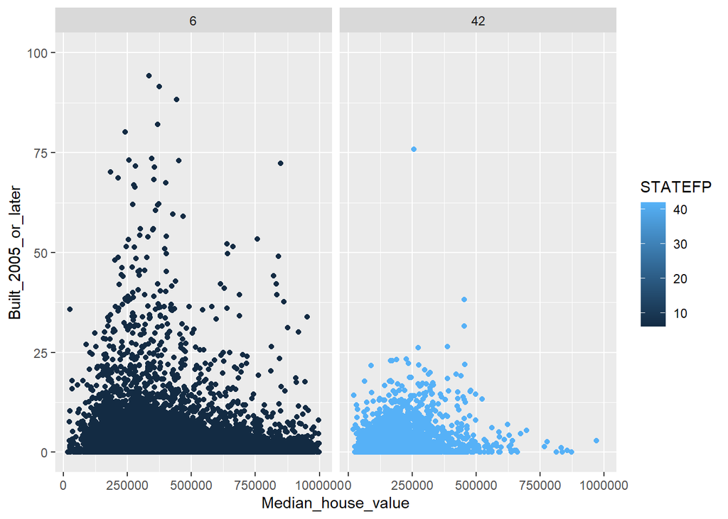

```r
ggplot(data = ca_pa) +
    geom_point(aes(x =Median_house_value, y = Built_2005_or_later, color = STATEFP))+
    facet_wrap(~ STATEFP)
```

3. *Nobody Home*  
   The vacancy rate is the fraction of housing units which are not occupied. The dataframe contains columns giving the total number of housing units for each Census tract, and the number of vacant housing units.
   1. Add a new column to the dataframe which contains the vacancy rate. What are the minimum, maximum, mean, and median vacancy rates?

```r
ca_pa.new <- mutate(ca_pa,the_vacancy_rate = Vacant_units / Total_units)
```

```
b. Plot the vacancy rate against median house value.
```